# STUDENT PERFORMANCE ANALYSIS

### To Predict The Final Grade (G3)

# INTRODUCTION

### Overview :

The goal of this project is to predict students' final academic performance using regression techniques. Academic success is influenced by various personal, social, and educational factors. By leveraging machine learning models, we aim to understand these influences and build a system that can accurately estimate a student's final grade (G3). Such predictions can be valuable for educators and policymakers to provide timely interventions and support.

### Dataset Description :

The dataset used in this project is the Student Performance Dataset, which contains detailed information about students from two Portuguese secondary schools. It includes 33 variables that capture a wide range of factors related to students' personal background, academic history, family support, and daily life habits. These variables include both categorical (like gender, parental job, and school support) and numerical features (like age, study time, and grades). The target variable, G3, represents the students' final grade, which we aim to predict using the other attributes in the dataset. This rich and diverse set of features makes it suitable for building and analyzing regression models to understand what influences student performance.

### The columns in the dataset are as follows :

- school : The school the student attends (GP = Gabriel Pereira or MS = Mousinho da Silveira)
- sex : Student's gender (F = female, M = male)
- age : Age of the student (numeric: 15–22).
- address : Home address type (U = urban, R = rural).
- famsize : Family size (LE3 = less or equal to 3, GT3 = greater than 3).
- Pstatus : Parent's cohabitation status (T = living together, A = apart).
- Medu : Mother's education level (0 = none to 4 = higher education).
- Fedu : Father's education level (0 = none to 4 = higher education).
- Mjob : Mother's job (e.g., teacher, health, services, at_home, other).
- Fjob : Father's job (same options as Mjob).
- reason : Reason for choosing this school (home, reputation, course preference, etc.).
- guardian : Student's guardian (mother, father, or other).
- traveltime : Time to get to school (1 = <15 min, 4 = >1 hour).
- studytime : Weekly study time (1 = <2 hours, 4 = >10 hours).
- failures : Number of past class failures (0 = none, 1 to 3 = failures).
- schoolsup : Extra educational support at school (yes or no).
- famsup : Family educational support (yes or no).
- paid : Extra paid classes in the subject (yes or no).
- activities : Participation in extracurricular activities (yes or no).
- nursery : Attended nursery school (yes or no).
- higher : Wants to take higher education (yes or no).
- internet : Internet access at home (yes or no).
- romantic : In a romantic relationship (yes or no).
- famrel : Quality of family relationships (1 = very bad to 5 = excellent).
- freetime : Free time after school (1 = very low to 5 = very high).
- goout : Going out with friends (1 = rarely to 5 = very often).
- Dalc : Workday alcohol consumption (1 = very low to 5 = very high).
- Walc : Weekend alcohol consumption (1 = very low to 5 = very high).
- health : Current health status (1 = very bad to 5 = very good).
- absences : Number of school absences.
- G1 : First period grade (numeric: 0–20).
- G2 : Second period grade (numeric: 0–20).
- G3 : Final grade (target variable; numeric: 0–20).

### Classification of features :

- Target Variable : G3
- Demographic : age, sex, school, address, famsize, Pstatus
- Parental background : Medu, Fedu, Mjob, Fjob, guardian
- Academic : studytime, failures, G1, G2
- Social/lifestyle : freetime, goout, Dalc, Walc, health, absences
- Support & activities: schoolsup, famsup, paid, activities, internet, nursery, romantic, higher, reason

### Approach

1. Data Loading
2. Descriptive Analysis
3. Data Cleaning and Preprocessing
4. Exploratory Data Analysis (EDA)
5. Feature Engineering
6. Outlier Treatment
7. Encoding
8. Scaling
9. Model Building
10. Visualizing Model Performance
11. Evaluating The Model
12. Plotting Feature Importance

# DATA LOADING

#### Loading Dependencies

```python
# Numerical operations and calculations
import numpy as np

# Data manipulation and analysis
import pandas as pd

# Data visualization and plotting
import matplotlib.pyplot as plt

# Enhanced data visualization and statistical graphics
import seaborn as sns

# Ignores warning messages.
import warnings
warnings.filterwarnings('ignore')
```

```python
# Label encoder for encoding categorical values
from sklearn.preprocessing import LabelEncoder
```

```python
# Standard scaler for scaling
from sklearn.preprocessing import StandardScaler
```

```python
# To split the data into train and test
from sklearn.model_selection import train_test_split
```

```python
pip install xgboost
```

```python
pip install lightgbm
```

```python
pip install catboost
```

```python
# Loading regression models
from sklearn.linear_model import LinearRegression, Ridge, Lasso, ElasticNet
from sklearn.tree import DecisionTreeRegressor
from sklearn.ensemble import RandomForestRegressor, GradientBoostingRegressor
from xgboost import XGBRegressor
from lightgbm import LGBMRegressor
from catboost import CatBoostRegressor
```

```python
# loading regression metrices
from sklearn.metrics import mean_absolute_error, mean_squared_error, r2_score
```

#### Loading Dataset

```python
std_data = pd.read_csv('./Student Performance Dataset.csv')
```

```python
std_data
```

|  | school | sex | age | address | famsize | Pstatus | Medu | Fedu | Mjob | Fjob | ... | famrel | freetime | goout | Dalc | Walc | health | absences | G1 | G2 | G3 |
| --- | --- | --- | --- | --- | --- | --- | --- | --- | --- | --- | --- | --- | --- | --- | --- | --- | --- | --- | --- | --- | --- |
| 0 | GP | F | 18 | U | GT3 | A | 4 | 4 | at_home | teacher | ... | 4 | 3 | 4 | 1 | 1 | 3 | 4 | 0 | 11 | 11 |
| 1 | GP | F | 17 | U | GT3 | T | 1 | 1 | at_home | other | ... | 5 | 3 | 3 | 1 | 1 | 3 | 2 | 9 | 11 | 11 |
| 2 | GP | F | 15 | U | LE3 | T | 1 | 1 | at_home | other | ... | 4 | 3 | 2 | 2 | 3 | 3 | 6 | 12 | 13 | 12 |
| 3 | GP | F | 15 | U | GT3 | T | 4 | 2 | health | services | ... | 3 | 2 | 2 | 1 | 1 | 5 | 0 | 14 | 14 | 14 |
| 4 | GP | F | 16 | U | GT3 | T | 3 | 3 | other | other | ... | 4 | 3 | 2 | 1 | 2 | 5 | 0 | 11 | 13 | 13 |
| ... | ... | ... | ... | ... | ... | ... | ... | ... | ... | ... | ... | ... | ... | ... | ... | ... | ... | ... | ... | ... | ... |
| 644 | MS | F | 19 | R | GT3 | T | 2 | 3 | services | other | ... | 5 | 4 | 2 | 1 | 2 | 5 | 4 | 10 | 11 | 10 |
| 645 | MS | F | 18 | U | LE3 | T | 3 | 1 | teacher | services | ... | 4 | 3 | 4 | 1 | 1 | 1 | 4 | 15 | 15 | 16 |
| 646 | MS | F | 18 | U | GT3 | T | 1 | 1 | other | other | ... | 1 | 1 | 1 | 1 | 1 | 5 | 6 | 11 | 12 | 9 |
| 647 | MS | M | 17 | U | LE3 | T | 3 | 1 | services | services | ... | 2 | 4 | 5 | 3 | 4 | 2 | 6 | 10 | 10 | 10 |
| 648 | MS | M | 18 | R | LE3 | T | 3 | 2 | services | other | ... | 4 | 4 | 1 | 3 | 4 | 5 | 4 | 10 | 11 | 11 |

649 rows × 33 columns

# DESCRIPTIVE ANALYSIS

```python
std_data.head(8)
```

|  | school | sex | age | address | famsize | Pstatus | Medu | Fedu | Mjob | Fjob | ... | famrel | freetime | goout | Dalc | Walc | health | absences | G1 | G2 | G3 |
| --- | --- | --- | --- | --- | --- | --- | --- | --- | --- | --- | --- | --- | --- | --- | --- | --- | --- | --- | --- | --- | --- |
| 0 | GP | F | 18 | U | GT3 | A | 4 | 4 | at_home | teacher | ... | 4 | 3 | 4 | 1 | 1 | 3 | 4 | 0 | 11 | 11 |
| 1 | GP | F | 17 | U | GT3 | T | 1 | 1 | at_home | other | ... | 5 | 3 | 3 | 1 | 1 | 3 | 2 | 9 | 11 | 11 |
| 2 | GP | F | 15 | U | LE3 | T | 1 | 1 | at_home | other | ... | 4 | 3 | 2 | 2 | 3 | 3 | 6 | 12 | 13 | 12 |
| 3 | GP | F | 15 | U | GT3 | T | 4 | 2 | health | services | ... | 3 | 2 | 2 | 1 | 1 | 5 | 0 | 14 | 14 | 14 |
| 4 | GP | F | 16 | U | GT3 | T | 3 | 3 | other | other | ... | 4 | 3 | 2 | 1 | 2 | 5 | 0 | 11 | 13 | 13 |
| 5 | GP | M | 16 | U | LE3 | T | 4 | 3 | services | other | ... | 5 | 4 | 2 | 1 | 2 | 5 | 6 | 12 | 12 | 13 |
| 6 | GP | M | 16 | U | LE3 | T | 2 | 2 | other | other | ... | 4 | 4 | 4 | 1 | 1 | 3 | 0 | 13 | 12 | 13 |
| 7 | GP | F | 17 | U | GT3 | A | 4 | 4 | other | teacher | ... | 4 | 1 | 4 | 1 | 1 | 1 | 2 | 10 | 13 | 13 |

8 rows × 33 columns

- Shows first 8 rows of the std_data DataFrame.

```python
std_data.tail(8)
```

|  | school | sex | age | address | famsize | Pstatus | Medu | Fedu | Mjob | Fjob | ... | famrel | freetime | goout | Dalc | Walc | health | absences | G1 | G2 | G3 |
| --- | --- | --- | --- | --- | --- | --- | --- | --- | --- | --- | --- | --- | --- | --- | --- | --- | --- | --- | --- | --- | --- |
| 641 | MS | F | 18 | R | GT3 | T | 2 | 2 | at_home | other | ... | 5 | 3 | 3 | 1 | 3 | 4 | 0 | 14 | 17 | 15 |
| 642 | MS | F | 17 | U | GT3 | T | 4 | 3 | teacher | other | ... | 5 | 5 | 4 | 1 | 1 | 1 | 0 | 6 | 9 | 11 |
| 643 | MS | F | 18 | R | GT3 | T | 4 | 4 | teacher | at_home | ... | 4 | 4 | 3 | 2 | 2 | 5 | 4 | 7 | 9 | 10 |
| 644 | MS | F | 19 | R | GT3 | T | 2 | 3 | services | other | ... | 5 | 4 | 2 | 1 | 2 | 5 | 4 | 10 | 11 | 10 |
| 645 | MS | F | 18 | U | LE3 | T | 3 | 1 | teacher | services | ... | 4 | 3 | 4 | 1 | 1 | 1 | 4 | 15 | 15 | 16 |
| 646 | MS | F | 18 | U | GT3 | T | 1 | 1 | other | other | ... | 1 | 1 | 1 | 1 | 1 | 5 | 6 | 11 | 12 | 9 |
| 647 | MS | M | 17 | U | LE3 | T | 3 | 1 | services | services | ... | 2 | 4 | 5 | 3 | 4 | 2 | 6 | 10 | 10 | 10 |
| 648 | MS | M | 18 | R | LE3 | T | 3 | 2 | services | other | ... | 4 | 4 | 1 | 3 | 4 | 5 | 4 | 10 | 11 | 11 |

8 rows × 33 columns

- Shows last 8 rows of the std_data DataFrame.

```python
std_data.sample(10)
```

|  | school | sex | age | address | famsize | Pstatus | Medu | Fedu | Mjob | Fjob | ... | famrel | freetime | goout | Dalc | Walc | health | absences | G1 | G2 | G3 |
| --- | --- | --- | --- | --- | --- | --- | --- | --- | --- | --- | --- | --- | --- | --- | --- | --- | --- | --- | --- | --- | --- |
| 500 | MS | M | 17 | U | GT3 | T | 1 | 2 | other | other | ... | 5 | 3 | 5 | 5 | 5 | 1 | 12 | 6 | 7 | 7 |
| 94 | GP | M | 15 | U | LE3 | T | 2 | 2 | services | health | ... | 4 | 3 | 4 | 1 | 1 | 4 | 2 | 11 | 12 | 12 |
| 436 | MS | F | 15 | R | LE3 | T | 1 | 1 | other | services | ... | 4 | 4 | 3 | 1 | 2 | 2 | 4 | 6 | 7 | 8 |
| 263 | GP | M | 18 | U | GT3 | T | 2 | 2 | other | services | ... | 5 | 5 | 4 | 3 | 5 | 2 | 16 | 8 | 7 | 8 |
| 437 | MS | F | 16 | R | GT3 | T | 0 | 2 | other | other | ... | 3 | 2 | 3 | 1 | 2 | 2 | 0 | 12 | 11 | 12 |
| 185 | GP | M | 16 | U | GT3 | T | 1 | 0 | other | other | ... | 4 | 3 | 2 | 1 | 1 | 3 | 0 | 16 | 17 | 18 |
| 413 | GP | M | 21 | R | LE3 | T | 1 | 1 | at_home | other | ... | 5 | 3 | 3 | 5 | 2 | 4 | 21 | 9 | 10 | 10 |
| 387 | GP | M | 18 | U | GT3 | T | 2 | 2 | other | other | ... | 5 | 4 | 2 | 1 | 2 | 5 | 6 | 15 | 14 | 15 |
| 125 | GP | M | 15 | U | GT3 | T | 3 | 4 | services | services | ... | 5 | 5 | 5 | 3 | 2 | 5 | 2 | 9 | 9 | 9 |
| 118 | GP | M | 17 | R | GT3 | T | 1 | 3 | other | other | ... | 5 | 2 | 4 | 1 | 4 | 5 | 14 | 12 | 11 | 11 |

10 rows × 33 columns

- Shows random sample of 10 rows from the std_data DataFrame.

```python
std_data.shape
```

```
(649, 33)
```

- DataFrame contains 33 columns and 649 rows.

```python
std_data.size
```

```
21417
```

- Dataframe contains 21417 total entries.

```python
std_data.columns
```

```
Index(['school', 'sex', 'age', 'address', 'famsize', 'Pstatus', 'Medu', 'Fedu',
       'Mjob', 'Fjob', 'reason', 'guardian', 'traveltime', 'studytime',
       'failures', 'schoolsup', 'famsup', 'paid', 'activities', 'nursery',
       'higher', 'internet', 'romantic', 'famrel', 'freetime', 'goout', 'Dalc',
       'Walc', 'health', 'absences', 'G1', 'G2', 'G3'],
      dtype='object')
```

- Displays the feature labels of the std_data dataframe.

```python
std_data.info()
```

```
<class 'pandas.core.frame.DataFrame'>
RangeIndex: 649 entries, 0 to 648
Data columns (total 33 columns):
 #   Column      Non-Null Count  Dtype
---  ------      --------------  -----
 0   school      649 non-null    object
 1   sex         649 non-null    object
 2   age         649 non-null    int64
 3   address     649 non-null    object
 4   famsize     649 non-null    object
 5   Pstatus     649 non-null    object
 6   Medu        649 non-null    int64
 7   Fedu        649 non-null    int64
 8   Mjob        649 non-null    object
 9   Fjob        649 non-null    object
```

[output cut: 25 more lines]

- The DataFrame has 649 rows and 33 columns, indicating a substantial dataset.
- The columns are a mix of object (categorical/string) and int64 (integer) data types. There are 17 object columns and 16 int64 columns.
- There are no missing values in the DataFrame, as indicated by the "non-null" count for each column.
- The DataFrame occupies approximately 167.4+ KB of memory.

```python
std_data.describe().T
```

|  | count | mean | std | min | 25% | 50% | 75% | max |
| --- | --- | --- | --- | --- | --- | --- | --- | --- |
| age | 649.0 | 16.744222 | 1.218138 | 15.0 | 16.0 | 17.0 | 18.0 | 22.0 |
| Medu | 649.0 | 2.514638 | 1.134552 | 0.0 | 2.0 | 2.0 | 4.0 | 4.0 |
| Fedu | 649.0 | 2.306626 | 1.099931 | 0.0 | 1.0 | 2.0 | 3.0 | 4.0 |
| traveltime | 649.0 | 1.568567 | 0.748660 | 1.0 | 1.0 | 1.0 | 2.0 | 4.0 |
| studytime | 649.0 | 1.930663 | 0.829510 | 1.0 | 1.0 | 2.0 | 2.0 | 4.0 |
| failures | 649.0 | 0.221880 | 0.593235 | 0.0 | 0.0 | 0.0 | 0.0 | 3.0 |
| famrel | 649.0 | 3.930663 | 0.955717 | 1.0 | 4.0 | 4.0 | 5.0 | 5.0 |
| freetime | 649.0 | 3.180277 | 1.051093 | 1.0 | 3.0 | 3.0 | 4.0 | 5.0 |
| goout | 649.0 | 3.184900 | 1.175766 | 1.0 | 2.0 | 3.0 | 4.0 | 5.0 |
| Dalc | 649.0 | 1.502311 | 0.924834 | 1.0 | 1.0 | 1.0 | 2.0 | 5.0 |
| Walc | 649.0 | 2.280431 | 1.284380 | 1.0 | 1.0 | 2.0 | 3.0 | 5.0 |
| health | 649.0 | 3.536210 | 1.446259 | 1.0 | 2.0 | 4.0 | 5.0 | 5.0 |
| absences | 649.0 | 3.659476 | 4.640759 | 0.0 | 0.0 | 2.0 | 6.0 | 32.0 |
| G1 | 649.0 | 11.399076 | 2.745265 | 0.0 | 10.0 | 11.0 | 13.0 | 19.0 |
| G2 | 649.0 | 11.570108 | 2.913639 | 0.0 | 10.0 | 11.0 | 13.0 | 19.0 |
| G3 | 649.0 | 11.906009 | 3.230656 | 0.0 | 10.0 | 12.0 | 14.0 | 19.0 |

- The table provides count, mean, standard deviation (std), minimum (min), 25th percentile (25%), median (50%), 75th percentile (75%), and maximum (max) for each variable.

# DATA CLEANING AND PREPROCESSING

#### Checking Missing Values

```python
std_data.isna().sum()
```

```
school        0
sex           0
age           0
address       0
famsize       0
Pstatus       0
Medu          0
Fedu          0
Mjob          0
Fjob          0
reason        0
guardian      0
traveltime    0
studytime     0
failures      0
schoolsup     0
famsup        0
paid          0
activities    0
nursery       0
higher        0
internet      0
romantic      0
famrel        0
freetime      0
goout         0
Dalc          0
Walc          0
health        0
absences      0
G1            0
G2            0
G3            0
dtype: int64
```

- No null values were detected in the columns.

#### Checking duplicate values

```python
std_data.duplicated().sum()
```

```
0
```

- No duplicate records were found in the dataset.

#### Checking each columns data type

```python
std_data.dtypes
```

```
school        object
sex           object
age            int64
address       object
famsize       object
Pstatus       object
Medu           int64
Fedu           int64
Mjob          object
Fjob          object
reason        object
guardian      object
traveltime     int64
studytime      int64
failures       int64
schoolsup     object
famsup        object
paid          object
activities    object
nursery       object
higher        object
internet      object
romantic      object
famrel         int64
freetime       int64
goout          int64
Dalc           int64
Walc           int64
health         int64
absences       int64
G1             int64
G2             int64
G3             int64
dtype: object
```

- 16 columns are of type int64, which are likely numerical values.
- 17 columns are of type object, which are likely categorical or string values.

#### Found the number of unique values of each column

```python
std_data.nunique()
```

```
school         2
sex            2
age            8
address        2
famsize        2
Pstatus        2
Medu           5
Fedu           5
Mjob           5
Fjob           5
reason         4
guardian       3
traveltime     4
studytime      4
failures       4
schoolsup      2
famsup         2
paid           2
activities     2
nursery        2
higher         2
internet       2
romantic       2
famrel         5
freetime       5
goout          5
Dalc           5
Walc           5
health         5
absences      24
G1            17
G2            16
G3            17
dtype: int64
```

#### Displayed the unique values in each column

```python
for i in std_data.columns:
    print(i)
    print(std_data[i].unique())
    print("-"*50)
    print("\n")
```

```
school
['GP' 'MS']
--------------------------------------------------


sex
['F' 'M']
--------------------------------------------------


age
[18 17 15 16 19 22 20 21]
--------------------------------------------------


address
['U' 'R']
--------------------------------------------------


famsize
['GT3' 'LE3']
--------------------------------------------------


Pstatus
['A' 'T']
--------------------------------------------------


Medu
[4 1 3 2 0]
--------------------------------------------------


Fedu
[4 1 2 3 0]
--------------------------------------------------


```

[output cut: 108 more lines]

```


G1
[ 0  9 12 14 11 13 10 15 17  8 16 18  7  6  5  4 19]
--------------------------------------------------


G2
[11 13 14 12 16 17  8 10 15  9  7  6 18 19  0  5]
--------------------------------------------------


G3
[11 12 14 13 17 15  7 10 16  9  8 18  6  0  1  5 19]
--------------------------------------------------
```

#### Checking the data distribution

```python
std_num_cols = std_data.select_dtypes(include = ['int'])
```

```python
std_num_cols
```

|  | age | Medu | Fedu | traveltime | studytime | failures | famrel | freetime | goout | Dalc | Walc | health | absences | G1 | G2 | G3 |
| --- | --- | --- | --- | --- | --- | --- | --- | --- | --- | --- | --- | --- | --- | --- | --- | --- |
| 0 | 18 | 4 | 4 | 2 | 2 | 0 | 4 | 3 | 4 | 1 | 1 | 3 | 4 | 0 | 11 | 11 |
| 1 | 17 | 1 | 1 | 1 | 2 | 0 | 5 | 3 | 3 | 1 | 1 | 3 | 2 | 9 | 11 | 11 |
| 2 | 15 | 1 | 1 | 1 | 2 | 0 | 4 | 3 | 2 | 2 | 3 | 3 | 6 | 12 | 13 | 12 |
| 3 | 15 | 4 | 2 | 1 | 3 | 0 | 3 | 2 | 2 | 1 | 1 | 5 | 0 | 14 | 14 | 14 |
| 4 | 16 | 3 | 3 | 1 | 2 | 0 | 4 | 3 | 2 | 1 | 2 | 5 | 0 | 11 | 13 | 13 |
| ... | ... | ... | ... | ... | ... | ... | ... | ... | ... | ... | ... | ... | ... | ... | ... | ... |
| 644 | 19 | 2 | 3 | 1 | 3 | 1 | 5 | 4 | 2 | 1 | 2 | 5 | 4 | 10 | 11 | 10 |
| 645 | 18 | 3 | 1 | 1 | 2 | 0 | 4 | 3 | 4 | 1 | 1 | 1 | 4 | 15 | 15 | 16 |
| 646 | 18 | 1 | 1 | 2 | 2 | 0 | 1 | 1 | 1 | 1 | 1 | 5 | 6 | 11 | 12 | 9 |
| 647 | 17 | 3 | 1 | 2 | 1 | 0 | 2 | 4 | 5 | 3 | 4 | 2 | 6 | 10 | 10 | 10 |
| 648 | 18 | 3 | 2 | 3 | 1 | 0 | 4 | 4 | 1 | 3 | 4 | 5 | 4 | 10 | 11 | 11 |

649 rows × 16 columns

#### Plotting the distribution

```
array([[<Axes: title={'center': 'age'}>,
        <Axes: title={'center': 'Medu'}>,
        <Axes: title={'center': 'Fedu'}>,
        <Axes: title={'center': 'traveltime'}>],
       [<Axes: title={'center': 'studytime'}>,
        <Axes: title={'center': 'failures'}>,
        <Axes: title={'center': 'famrel'}>,
        <Axes: title={'center': 'freetime'}>],
       [<Axes: title={'center': 'goout'}>,
        <Axes: title={'center': 'Dalc'}>,
        <Axes: title={'center': 'Walc'}>,
        <Axes: title={'center': 'health'}>],
       [<Axes: title={'center': 'absences'}>,
        <Axes: title={'center': 'G1'}>, <Axes: title={'center': 'G2'}>,
        <Axes: title={'center': 'G3'}>]], dtype=object)
```

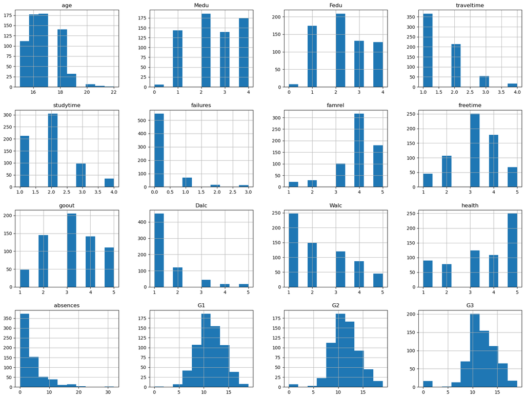

```python
std_num_cols.hist(figsize = (20,15))
```

- Numerical columns shows skewed distribution.

#### Grouping

```python
# Final Grade Distribution by School
avg_grade_by_school = std_data.groupby('school')['G3'].mean()
print(avg_grade_by_school)
```

```
school
GP    12.576832
MS    10.650442
Name: G3, dtype: float64
```

- Average final grade (G3) by school

```python
# Categorize G3 into grade bands
std_data['grade_band'] = pd.cut(std_data['G3'], bins=[0, 9, 14, 20], labels=['Low', 'Medium', 'High'])

# Average study time per grade band
studytime_band = std_data.groupby('grade_band')['studytime'].mean()
print(studytime_band)
```

```
grade_band
Low       1.635294
Medium    1.913876
High      2.229008
Name: studytime, dtype: float64
```

- Study Time Distribution Across Different Grade Bands

# EXPLORATORY DATA ANALYSIS (EDA)

[figure not shown]

### UNIVARIANT ANALYSIS

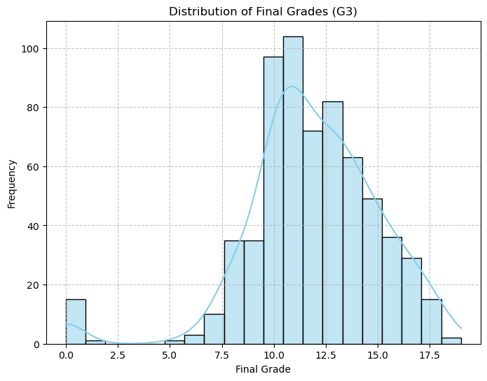

```python
plt.figure(figsize=(8, 6))
sns.histplot(std_data['G3'], bins=20, kde=True, color='skyblue')
plt.title('Distribution of Final Grades (G3)')
plt.xlabel('Final Grade')
plt.ylabel('Frequency')
plt.grid(True, linestyle='--', alpha=0.7)
plt.show()
```

```python
numerical_cols1 = ['Dalc', 'Walc', 'traveltime', 'studytime', 'freetime']
```

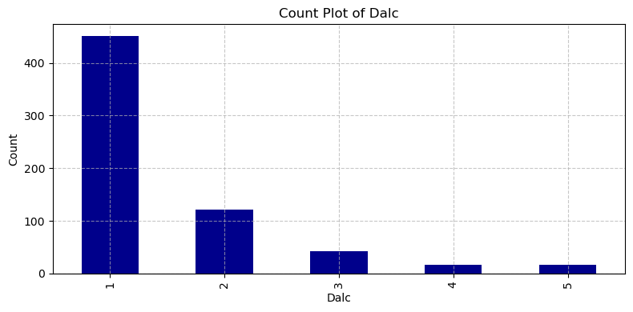

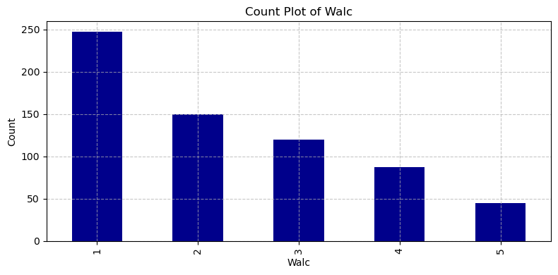

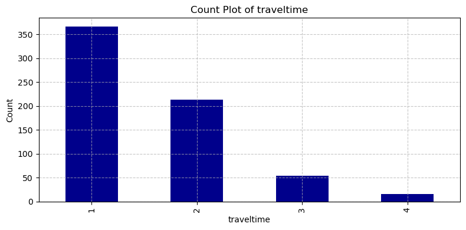

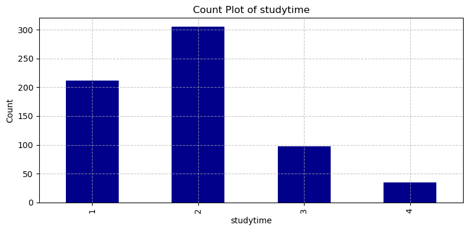

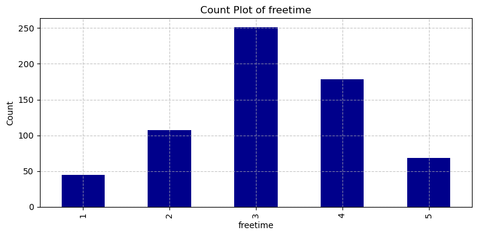

```python
for col in numerical_cols1:
    plt.figure(figsize=(8, 4))
    std_data[col].value_counts().sort_index().plot(kind='bar', color='darkblue')

    plt.title(f'Count Plot of {col}')
    plt.xlabel(col)
    plt.ylabel('Count')

    plt.grid(True, linestyle='--', alpha=0.7)

    plt.tight_layout()
    plt.show()
```

- The plot indicates that the variable "Dalc" might be related to a phenomenon or characteristic where the value "1" is predominant or represents a baseline condition.
- The Walc data suggests that category 1 is the most prevalent, while category 5 is the least common.
- The data suggests that the most common travel time is 1, indicating that the majority of individuals or instances have a relatively short travel time.
- The count plot od studytime suggests that the majority of the data points fall within category 2, indicating that this is the most common study time. Category 1 is the second most frequent, while categories 3 and 4 are less common.
- The data suggests that the majority of respondents have a moderate amount of free time, as indicated by the peak at category 3.

### BIVARIANT ANALYSIS

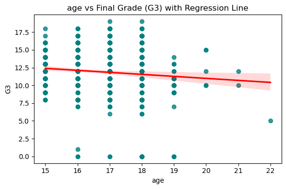

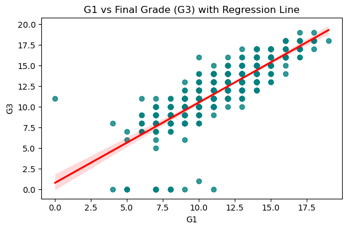

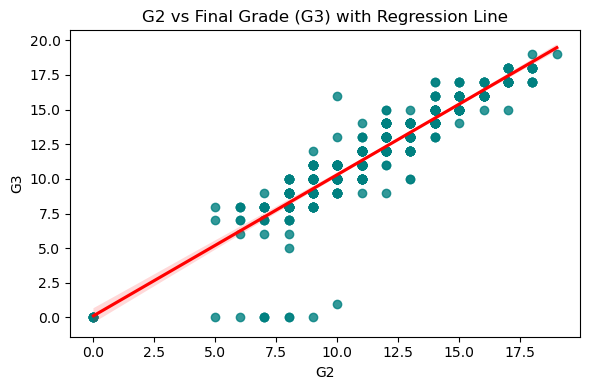

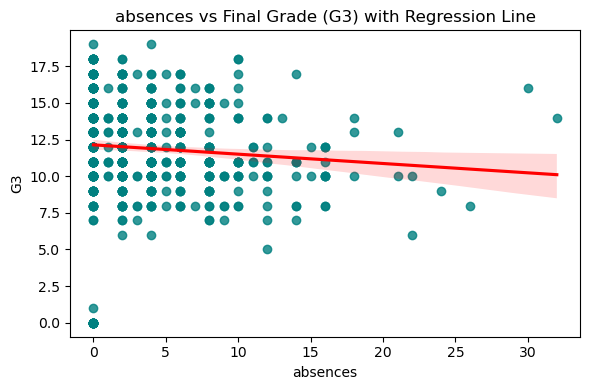

```python
for col in ['age', 'G1', 'G2', 'absences']:
    plt.figure(figsize=(6, 4))
    sns.regplot(data=std_data, x=col, y='G3', scatter_kws={'color': 'teal'}, line_kws={'color': 'red'})
    plt.title(f'{col} vs Final Grade (G3) with Regression Line')
    plt.tight_layout()
    plt.show()
```

- The regression line, depicted in red, exhibits a negative slope, indicating a downward trend in G3 as age increases.
- The scatterplot reveals a moderate to strong positive correlation between G1 and G3, as evidenced by the upward trend of the data points and the regression line.
- The positive correlation between G1 and G3 suggests that G1 is a significant predictor of G3.
- The strong positive correlation between G2 and G3 suggests that G2 is a good predictor of G3.
- The negative correlation suggests that students with more absences tend to perform poorly in their final grades.

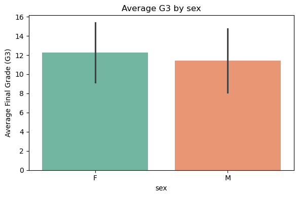

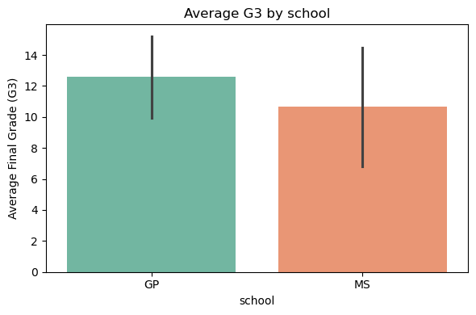

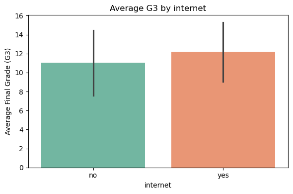

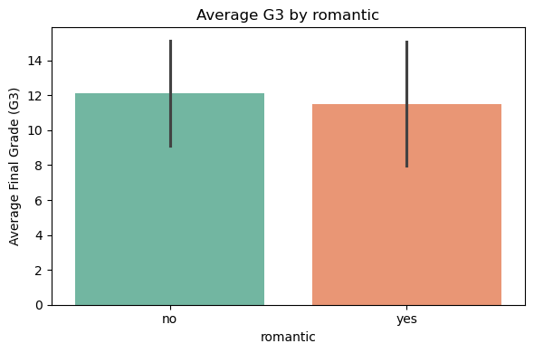

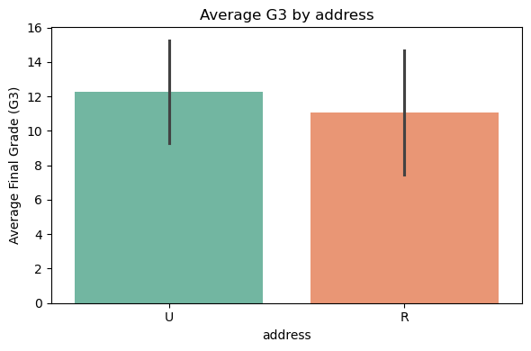

```python
for col in ['sex', 'school', 'internet', 'romantic','address']:
    plt.figure(figsize=(6, 4))
    sns.barplot(x=std_data[col], y=std_data['G3'], palette='Set2', estimator='mean', errorbar='sd')
    plt.title(f'Average G3 by {col}')
    plt.xlabel(col)
    plt.ylabel('Average Final Grade (G3)')
    plt.tight_layout()
    plt.show()
```

### MULTIVARIANT ANALYSIS

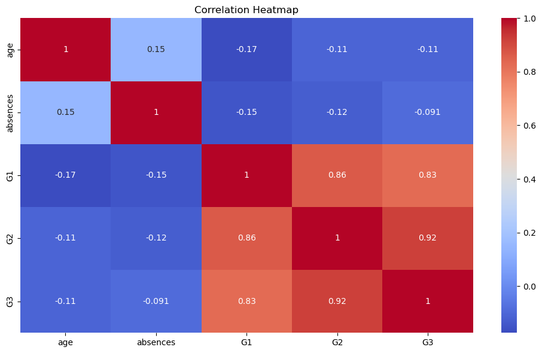

```python
plt.figure(figsize=(10, 6))
sns.heatmap(std_data[['age', 'absences', 'G1', 'G2', 'G3']].corr(), annot=True, cmap='coolwarm')
plt.title('Correlation Heatmap')
plt.tight_layout()
plt.show()
```

- The strong positive correlations among G1, G2, and G3 suggest that these variables are closely related and may be measuring similar aspects.
- The weak correlations between "age" and "absences" with the other variables indicate that these factors may not be strongly influencing the values of G1, G2, and G3.
- The negative correlations between "age" and G1, as well as between "absences" and the G variables, could indicate that older students or those with more absences tend to perform slightly worse in these areas.

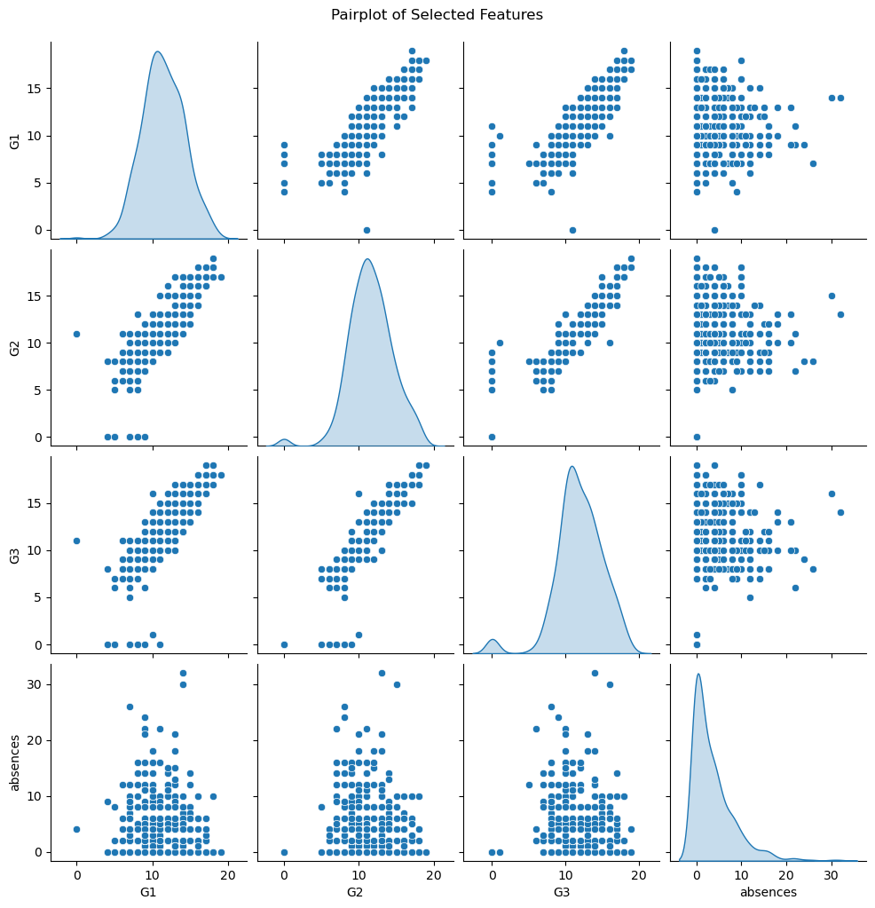

```python
sns.pairplot(std_data[['G1', 'G2', 'G3', 'absences']], diag_kind='kde')
plt.suptitle('Pairplot of Selected Features', y=1.02)
plt.show()
```

- The strong positive correlations between G1, G2, and G3 suggest that these variables are measuring related constructs.
- The skewed distribution of absences may indicate that there are some outliers or extreme values in the data.
- The relationships between G1, G2, G3, and absences are not straightforward, suggesting that there may be other factors at play.

```python
# Calculate average G3 score per gender
avg_g3_by_sex = std_data.groupby('sex')['G3'].mean()
```

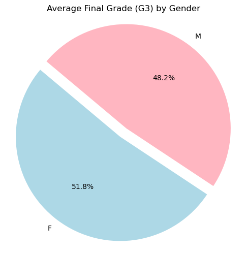

```python
# Pie chart
plt.figure(figsize=(6, 6))
plt.pie(avg_g3_by_sex, labels=avg_g3_by_sex.index, autopct='%1.1f%%', startangle=140,explode = (0.1,0), colors=['lightblue', 'lightpink'])
plt.title('Average Final Grade (G3) by Gender')
plt.axis('equal')
plt.show()
```

- Female Students: 51.8%
- Male Students: 48.2%
- The pie chart reveals that female students have a slightly higher average final grade (G3) compared to male students, with a difference of 3.6 percentage points.
- This suggests that, on average, female students tend to perform better academically than their male counterparts in the context represented by the data.

# FEATURE ENGINEERING

#### Creating a new column Mean

```python
std_data['Mean'] = (std_data['G1'] + std_data['G2'] + std_data['G3'])/3
```

```python
std_data
```

|  | school | sex | age | address | famsize | Pstatus | Medu | Fedu | Mjob | Fjob | ... | goout | Dalc | Walc | health | absences | G1 | G2 | G3 | grade_band | Mean |
| --- | --- | --- | --- | --- | --- | --- | --- | --- | --- | --- | --- | --- | --- | --- | --- | --- | --- | --- | --- | --- | --- |
| 0 | GP | F | 18 | U | GT3 | A | 4 | 4 | at_home | teacher | ... | 4 | 1 | 1 | 3 | 4 | 0 | 11 | 11 | Medium | 7.333333 |
| 1 | GP | F | 17 | U | GT3 | T | 1 | 1 | at_home | other | ... | 3 | 1 | 1 | 3 | 2 | 9 | 11 | 11 | Medium | 10.333333 |
| 2 | GP | F | 15 | U | LE3 | T | 1 | 1 | at_home | other | ... | 2 | 2 | 3 | 3 | 6 | 12 | 13 | 12 | Medium | 12.333333 |
| 3 | GP | F | 15 | U | GT3 | T | 4 | 2 | health | services | ... | 2 | 1 | 1 | 5 | 0 | 14 | 14 | 14 | Medium | 14.000000 |
| 4 | GP | F | 16 | U | GT3 | T | 3 | 3 | other | other | ... | 2 | 1 | 2 | 5 | 0 | 11 | 13 | 13 | Medium | 12.333333 |
| ... | ... | ... | ... | ... | ... | ... | ... | ... | ... | ... | ... | ... | ... | ... | ... | ... | ... | ... | ... | ... | ... |
| 644 | MS | F | 19 | R | GT3 | T | 2 | 3 | services | other | ... | 2 | 1 | 2 | 5 | 4 | 10 | 11 | 10 | Medium | 10.333333 |
| 645 | MS | F | 18 | U | LE3 | T | 3 | 1 | teacher | services | ... | 4 | 1 | 1 | 1 | 4 | 15 | 15 | 16 | High | 15.333333 |
| 646 | MS | F | 18 | U | GT3 | T | 1 | 1 | other | other | ... | 1 | 1 | 1 | 5 | 6 | 11 | 12 | 9 | Low | 10.666667 |
| 647 | MS | M | 17 | U | LE3 | T | 3 | 1 | services | services | ... | 5 | 3 | 4 | 2 | 6 | 10 | 10 | 10 | Medium | 10.000000 |
| 648 | MS | M | 18 | R | LE3 | T | 3 | 2 | services | other | ... | 1 | 3 | 4 | 5 | 4 | 10 | 11 | 11 | Medium | 10.666667 |

649 rows × 35 columns

# OUTLIER DETECTION

#### Plotting the box plot to find the outlier

```python
std_num_cols = std_data.select_dtypes(include = ['int','float'])
```

```python
std_num_cols
```

|  | age | Medu | Fedu | traveltime | studytime | failures | famrel | freetime | goout | Dalc | Walc | health | absences | G1 | G2 | G3 | Mean |
| --- | --- | --- | --- | --- | --- | --- | --- | --- | --- | --- | --- | --- | --- | --- | --- | --- | --- |
| 0 | 18 | 4 | 4 | 2 | 2 | 0 | 4 | 3 | 4 | 1 | 1 | 3 | 4 | 0 | 11 | 11 | 7.333333 |
| 1 | 17 | 1 | 1 | 1 | 2 | 0 | 5 | 3 | 3 | 1 | 1 | 3 | 2 | 9 | 11 | 11 | 10.333333 |
| 2 | 15 | 1 | 1 | 1 | 2 | 0 | 4 | 3 | 2 | 2 | 3 | 3 | 6 | 12 | 13 | 12 | 12.333333 |
| 3 | 15 | 4 | 2 | 1 | 3 | 0 | 3 | 2 | 2 | 1 | 1 | 5 | 0 | 14 | 14 | 14 | 14.000000 |
| 4 | 16 | 3 | 3 | 1 | 2 | 0 | 4 | 3 | 2 | 1 | 2 | 5 | 0 | 11 | 13 | 13 | 12.333333 |
| ... | ... | ... | ... | ... | ... | ... | ... | ... | ... | ... | ... | ... | ... | ... | ... | ... | ... |
| 644 | 19 | 2 | 3 | 1 | 3 | 1 | 5 | 4 | 2 | 1 | 2 | 5 | 4 | 10 | 11 | 10 | 10.333333 |
| 645 | 18 | 3 | 1 | 1 | 2 | 0 | 4 | 3 | 4 | 1 | 1 | 1 | 4 | 15 | 15 | 16 | 15.333333 |
| 646 | 18 | 1 | 1 | 2 | 2 | 0 | 1 | 1 | 1 | 1 | 1 | 5 | 6 | 11 | 12 | 9 | 10.666667 |
| 647 | 17 | 3 | 1 | 2 | 1 | 0 | 2 | 4 | 5 | 3 | 4 | 2 | 6 | 10 | 10 | 10 | 10.000000 |
| 648 | 18 | 3 | 2 | 3 | 1 | 0 | 4 | 4 | 1 | 3 | 4 | 5 | 4 | 10 | 11 | 11 | 10.666667 |

649 rows × 17 columns

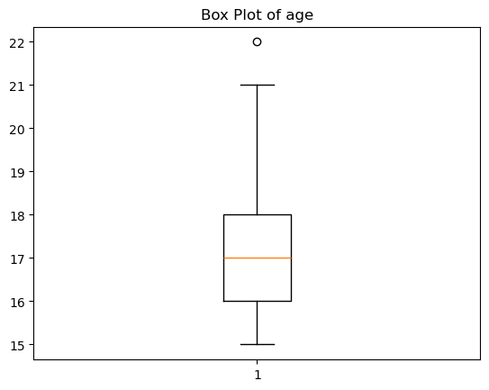

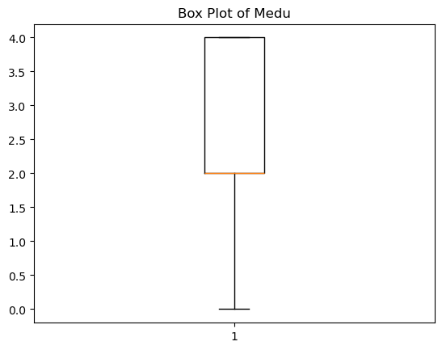

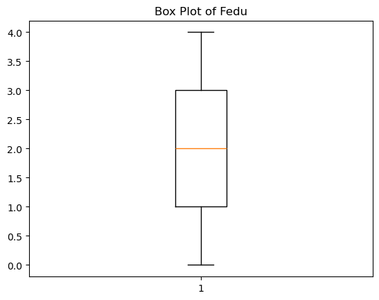

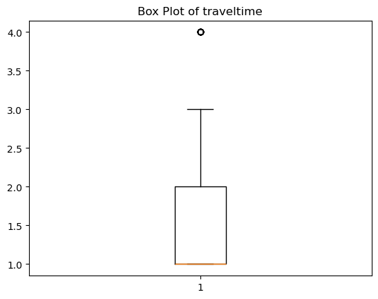

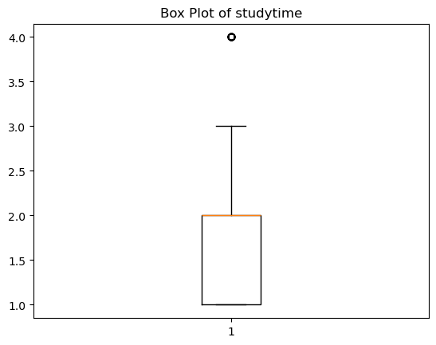

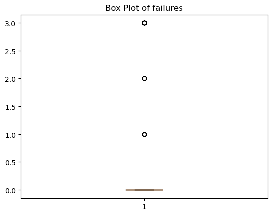

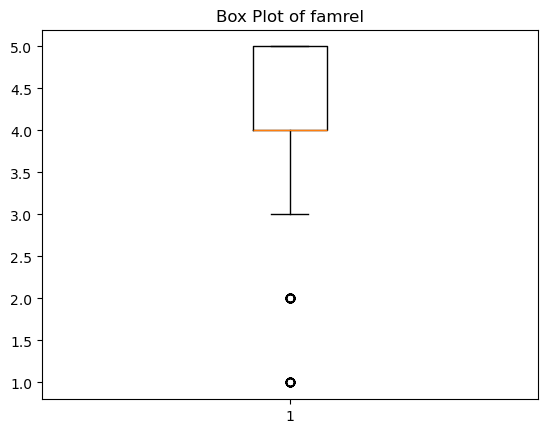

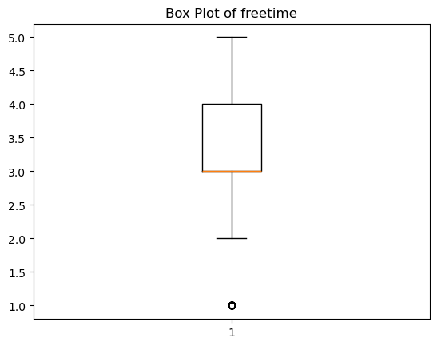

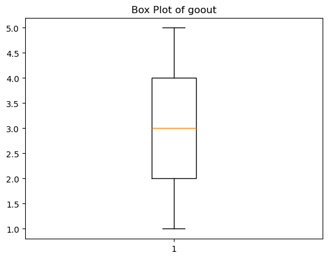

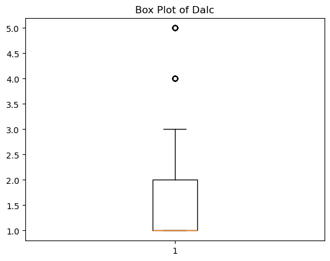

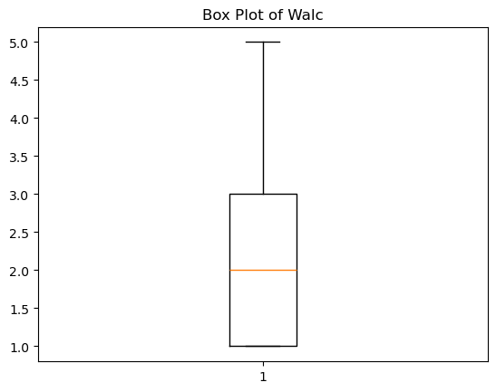

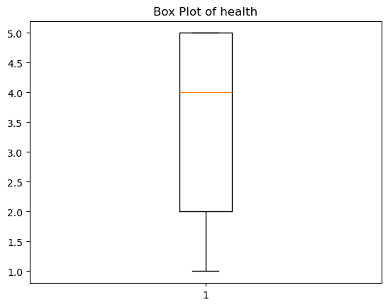

[5 more figures not shown]

```python
for i in std_num_cols:
    plt.boxplot(std_num_cols[i])
    plt.title(f"Box Plot of {i}")
    plt.show()
```